# Practical 2: Foundations (Part 1)

Getting to grips with the ‘Basics’

This week is focussed on ensuring that you’re able to run Jupyter notebooks locally (i.e. on your own computer) and are comfortable with the basics of Python: if you’ve already done Code Camp then this will be a refresher and you’ll have plenty of time to get to grips with Git and GitHub, which often presents significant practical challenges. You *should* find this notebook quite straightforward, but take any challenges as a sign that you need to keep practicing since subsequent weeks will build on these foundational concepts.

## Learning Outcomes

- You have familiarised yourself with how to add and synchronise new files in Git/GitHub.
- You have refamiliarised yourself with Python operators and precedence.
- You have refamiliarised yourself with Python logic and lists.

These are the foundations for subsequent weeks, so if you are still confused at the end of the practical please look at [Code Camp](https://jreades.github.io/code-camp/) and re-run this practical from scratch if need be!

# Starting the Practical

The process for every week will be the same: download the notebook to your `fsds` folder; `add`, `commit`, and `push` the notebook in Git; switch over to `JupyterLab` (which will be running in Podman) and get to work. When you’re done for the day, save your changes to the file, then `add`, `commit`, and `push` your work to save the completed notebook.

In your GIS class you will be using the Git Desktop, and if that works for you then I won’t insist you use the Terminal; however, I will note that Git only started to make sense (and problems only began to become easier to resolve) once I switched to the Terminal from Git Desktop.

## Download the Notebook

So for this week, visit the [Week 2 of FSDS page](https://jreades.github.io/fsds/sessions/week2.html#practical) you’ll see that there is a ‘preview’ link and a a ‘download’ link in the [Practical section](https://jreades.github.io/fsds/sessions/week2.html#practical). If you click the `preview` link you will be taken to the GitHub page for the notebook where it has been ‘rendered’ as a web page. But to make the notebook useable on *your* computer, you need to `download` the IPYNB file.

So now:

1. Click on the `Download` link.
2. The file should download automatically, but *if* you see a page of raw code, select `File` then `Save Page As...`.
3. Make sure you know where to find the file (e.g. Downloads or Desktop).
4. Move the file to your Git repository folder (e.g. `~/Documents/CASA/fsds/`)
5. Check to see if your browser has added `.txt` to the file name:
   - If no, then you can move to adding the file.
   - If yes, then you can either fix the name in the Finder/Windows Explore, or you can do this in the Terminal using `mv <name_of_practical>.ipynb.txt <name_of_practical>.ipynb` (you can even do this in JupyterLab’s terminal if it’s already running).

## Add the Notebook to Git

1. Now you can add it to Git and synchronise it with GitHub:
   1. `git add <name_of_practical>.ipynb`
   2. `git commit -m "Adding Practical 2"`
   3. `git push`

The file should now be in your GitHub repository in its ‘original’ format (before you write or run any code).

## Switch to JupyterLab

I am assuming that you are already running JupyterLab via Podman using the command that we saw in Week 1 and on the [CASA Computing Platform](https://ucl-casa.github.io/sds/). However, if you called `podman run ...` from the ‘wrong place’ then you might not be able to see the recently added practical in your work folder.

It that’s the case, then you will need to stop the container so please see the section below. You need to remember that the startup command is something like:

```bash
podman run ... -v "$(pwd):/home/jovyan/work" ...
```

The `-v` (short for *volume*) tells Podman what part of *your* computer should be connected to place in container where we store the work (`/home/jovyan/work`). `pwd` is short for ‘print working directory’ and is the location where you ran the startup command! So we’re talking about the location on *your* computer when you access the `work` folder from Jupyter Lab:

- On a Mac, if you just opened a new Terminal and run the Podman startup command then it will be your `$HOME` (also known as `~`) directory (e.g. `/Users/<your username>/`) because that’s where new Terminal windows start by default.
- On a Windows machine it *may* be your `$HOME` directory but we can’t promise.

Perhaps a video will help clarify?

**Note**: Docker and Podman are basically the same!

[video not shown]

## Is the Container Running?

1. Open the Podman Desktop from the menu and make sure that you select the `Containers` tab. You *should* see something like this if the container is *running* and *available*:

[figure not shown]

Container running

1. From the Terminal you should be able to run: `podman ps`. This will give you output something like this:

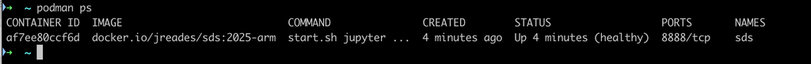

Container running from Terminal

### Connect to Jupyter Lab

Once you know the container is running you can connected to Jupyter Lab on [localhost:8888](http://localhost:8888/lab/tree/work/) and should see something like this:

[figure not shown]

Screenshot of JupyterLab

You’re connected!

# Running the Notebook

## Hello World!

Nearly every introduction to programming course starts with the famous ‘Hello World!’, so why do anything different?

From *within Jupyter Lab* you should now able to create a new notebook:

1. Click on the `Python 3` tile in the `Notebook` section.
2. You should see a new tab open with a new notebook (title: `Untitled.ipynb`).
3. In the first cell type `print('Hello World!')`.
4. Click the `Run` button (▶) in the menu above the notebook.
5. You should see Python output `Hello World!` below the cell.

Any time you want to run code you click on the right-triangle (▶); it’s in the area between the clipboard 📋 (for copying) and the ■ (for stopping running code).

So when you run:

```python
print('Hello World!')
```

Hopefully, the following appears directly *below* the code:

`Hello World!`

**Tip**

You can always click the ▶ icon above, but it will be much *faster* to get into the habit of type `Ctrl`+`Enter` instead when you have placed your cursor in a code cell. This is also how to turn a Markdown cell back into display text.

You can now close this notebook. Unless you created this notebook in the `work` folder, you will not be able to save it permanently. That’s fine.

## Starting the Practical Notebook

*Now* from *within Jupyter Lab* you should start the Practical 2 notebook:

1. Starting from the `work` folder, navigate to your repo folder where you saved this notebook (`Practical-02-Foundations_1.ipynb`).
2. Double-click the notebook file and the notebook should appear on the right-hand side. If all you see is reams of plain text then there is probably still a `.txt` extension on your notebook file that hasn’t been removed.

Now you can run code directly in your browser, so let’s try it!